# A Test of Time-Based Sample Stratification

Tyler Burleigh, PhD[^1]

August, 2018

# Introduction

In 2017, political scientists [Casey](https://www.loganscasey.com) et al. (2017) published a paper titled *Intertemporal Differences Among MTurk Workers: Time-Based Sample Variations and Implications for Online Data Collection*. In this paper, they showed how the demographic characteristics of MTurk samples vary by time (time of day, day of week). For example, one finding they reported was that you’re more likely to get participants from *Eastern* time zones if you recruit at **10 a.m. EST**, but you’ll get more workers from *Western* time zones if you recruit at **10 p.m. EST**. Of course, the differences went well beyond time zones and into various other demographic characteristics like age, sex, race, and even some personality traits.

After reading this paper, it occurred to me that this issue of *time-based sample variation* might be solved using **time-based sample stratification**. The logic goes like this: If the issue is sample bias resulting from posting large batches of HITs at specific times of day, then posting many smaller “micro-batches” at equal intervals spaced out across time should lead to better representation across time. In turn, this might address any demographic differences related to time.

Here I present the results from a secondary analysis of a study (`N = 197`) in which I applied this time-based sample stratification technique.

# Stratification Script

To perform time-based sample stratification, I used [`MTurkR`](https://github.com/cloudyr/MTurkR) to interface with the MTurk API. I wrote a `repeat` loop that would post a HIT with 9 assignments once every hour, and at the end of each hour it would also expire any assignments remaining from previous HIT and assign a qualification to anyone who just participated (so they couldn’t participate again).

```
## Run in sandbox?
sandbox_val <- "FALSE"

## Annotation
my_annotation <- "MY_ANNOTATION"

# Qualification reqirement (hasn't done the task yet)
my_qual <- GenerateQualificationRequirement(
                        qual = "MY_QUALIFICATION_ID",
                        comparator = "DoesNotExist",
                        value = "",
                        preview = "TRUE")

# Create HIT type
newhittype <- RegisterHITType(
  title = "15-minute academic survey",
  description = "Complete a 15-minute research survey",
  reward = "1.50",
  duration = seconds(hours = 3),
  keywords = "academic, research, study, survey",
  qual.req = my_qual,
  sandbox = sandbox_val
)

# The Loop
repeat {

  # Create HIT
  currentHIT <-  CreateHIT(
    hit.type = newhittype$HITTypeId,
    assignments = 9,
    expiration = 3600,
    annotation = my_annotation,
    sandbox = sandbox_val,
    hitlayoutid = my_hitlayoutid
  )

  # Wait some duration ()
  Sys.sleep(3600)

  # Expire HIT
  ExpireHIT(hit = currentHIT$HITId, sandbox = sandbox_val )

  # Get assignments
  assns <- GetAssignments(hit = currentHIT$HITId, sandbox = sandbox_val)

  # (De)Qualify workers from next HIT of same type
  AssignQualification(qual = "MY_QUALIFICATION_ID", workers = assns$WorkerId)
}
```

# Sample Frame

The graphs below show the actual HITs posted and HITs completed as a function of time. As we see, there was pretty good coverage. (There are a few spikes reflecting times when a bit of manual intervention was necessary.)

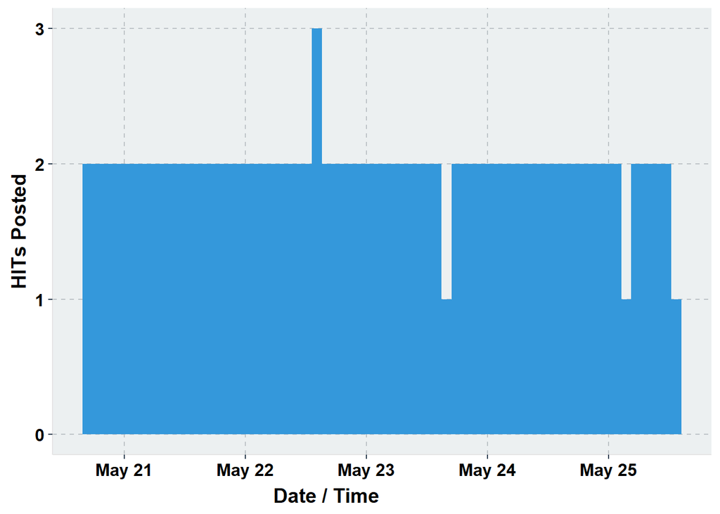

```r
load("HIT times.R")
load("weighted_times.R")

ggplot2.histogram(data=times, xName='times', xtitle="Date / Time", ytitle="HITs Posted", bins=60)
```

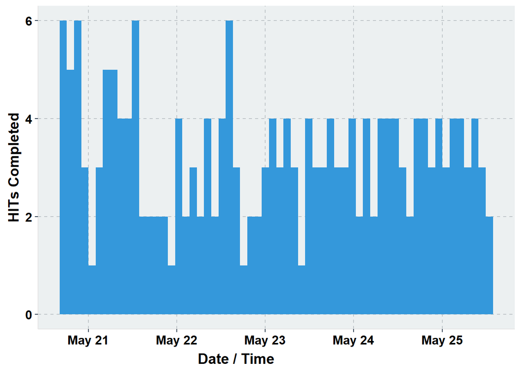

```r
ggplot2.histogram(data=weighted_times, xName='weighted_times', xtitle="Date / Time", ytitle="HITs Completed", bins=60)
```

# Results

Now that I’ve shown the stratification process works to get pretty good representation across time, we’ll next look at the demographics of the sample. For these analyses, 15 participants were dropped due to data quality issues on non-demographic questions (e.g., missing attention check questions), leaving a sample of `n = 182` for the analyses.

## Age

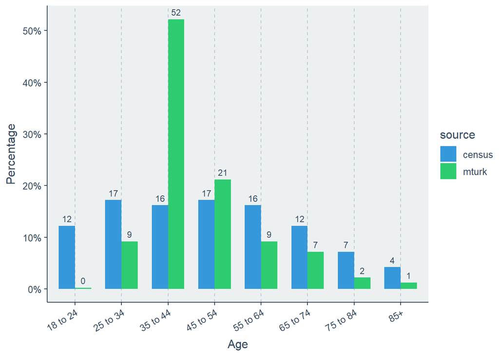

```r
#########################################
# AGE

ages <- getCensus(name = "pep/charage",
          vintage = 2017,
          vars = c("POP", "AGE"),
          region = "state:*")

total_c <- sum(as.numeric(ages[which(ages$AGE > 17 & ages$AGE < 999),]$POP))
total_mturk <- NROW(d)

age_arr <- as.data.frame(matrix(0, ncol = 3, nrow = 0))
age_arr <- rbind(age_arr,
              c("census", "18 to 24", round(sum(as.numeric(ages[which(ages$AGE >= 18 & ages$AGE <= 24),]$POP)) / total_c * 100)),
              c("census", "25 to 34", round(sum(as.numeric(ages[which(ages$AGE >= 25 & ages$AGE <= 34),]$POP)) / total_c * 100)),
              c("census", "35 to 44", round(sum(as.numeric(ages[which(ages$AGE >= 35 & ages$AGE <= 44),]$POP)) / total_c * 100)),
              c("census", "45 to 54", round(sum(as.numeric(ages[which(ages$AGE >= 45 & ages$AGE <= 54),]$POP)) / total_c * 100)),
              c("census", "55 to 64", round(sum(as.numeric(ages[which(ages$AGE >= 55 & ages$AGE <= 64),]$POP)) / total_c * 100)),
              c("census", "65 to 74", round(sum(as.numeric(ages[which(ages$AGE >= 65 & ages$AGE <= 74),]$POP)) / total_c * 100)),
              c("census", "75 to 84", round(sum(as.numeric(ages[which(ages$AGE >= 75 & ages$AGE <= 84),]$POP)) / total_c * 100)),
              c("census", "85+", round(sum(as.numeric(ages[which(ages$AGE >= 85 & ages$AGE < 999),]$POP)) / total_c * 100)),

              c("mturk", "18 to 24", round(NROW(d[which(d$Age == 1),]) / total_mturk * 100)),
              c("mturk", "25 to 34", round(NROW(d[which(d$Age == 2),]) / total_mturk * 100)),
              c("mturk", "35 to 44", round(NROW(d[which(d$Age == 3),]) / total_mturk * 100)),
              c("mturk", "45 to 54", round(NROW(d[which(d$Age == 4),]) / total_mturk * 100)),
              c("mturk", "55 to 64", round(NROW(d[which(d$Age == 5),]) / total_mturk * 100)),
              c("mturk", "65 to 74", round(NROW(d[which(d$Age == 6),]) / total_mturk * 100)),
              c("mturk", "75 to 84", round(NROW(d[which(d$Age == 7),]) / total_mturk * 100)),
              c("mturk", "85+", round(NROW(d[which(d$Age == 8),]) / total_mturk * 100))
)

colnames(age_arr) <- c("source", "age", "pct")
age_arr$pct <- as.numeric(as.character(age_arr$pct))
age_arr$pct <- age_arr$pct + 0.2

ggplot(age_arr, aes(x=age, y=pct, fill=source)) +
  scale_y_continuous(labels = function(x) paste0(x, "%")) +
  geom_bar(stat="identity", position = "dodge", width=0.7) +
  geom_text(aes(label = round(pct), y= round(pct)),  vjust = -0.75, size = 3, position=position_dodge(width=0.7)) +
  theme(panel.grid.major.y = element_blank(), panel.grid.minor.y = element_blank(), axis.text.x=element_text(angle = 30, hjust = 1)) +
  xlab("Age") + ylab("Percentage")
```

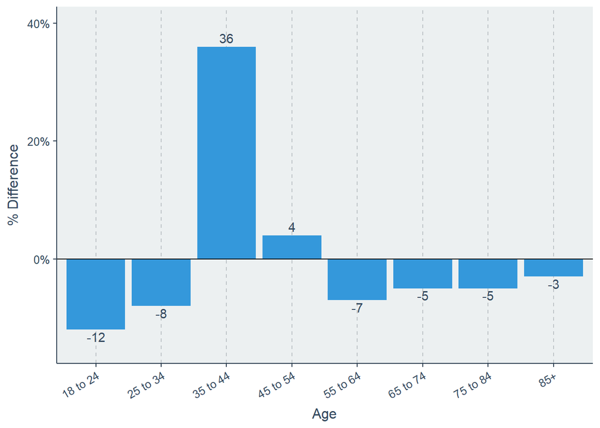

```r
###################
### Diff plot
age_diff <- as.data.frame(matrix(0, ncol = 2, nrow = 0))
for(i in 1:length(unique(age_arr$age))) {
  age <- unique(age_arr$age)[i]
  item <- c(as.character(age), age_arr[which(age_arr$age == age),]$pct[2] - age_arr[which(age_arr$age == age),]$pct[1])
  age_diff <- rbind(age_diff, item, stringsAsFactors=FALSE)
}
colnames(age_diff) <- c("age", "pct")
age_diff$pct <- as.numeric(as.character(age_diff$pct))

suppressMessages(
  ggplot(age_diff, aes(x=age, y=pct))+
    geom_bar(stat="identity", position="dodge") +
    geom_text(aes(label = pct, vjust = ifelse(pct >= 0, -0.4, 1.2))) +
    scale_y_continuous(labels = function(x) paste0(x, "%"), limits = c(-15, 40)) +
    theme(panel.grid.major.y = element_blank(), panel.grid.minor.y = element_blank(), axis.text.x=element_text(angle = 30, hjust = 1)) +
    xlab("Age") + ylab("% Difference") +
    geom_hline(yintercept=0, color="black")
)
```

```r
##########################################
```

## More to come

This document is a work in progress, check back later!

# References

Casey, L. S., Chandler, J., Levine, A. S., Proctor, A., & Strolovitch, D. Z. (2017). Intertemporal differences among MTurk workers: Time-based sample variations and implications for online data collection. SAGE Open, 7(2). https://doi.org/10.1177/2158244017712774

[^1]: Tyler Burleigh, PhD; Data Cubed, LLC; tyler@datacubed.com